# Sparse Matrices

In several real life applications matrices have often very large dimensions and contain a large number of zero entries. Matrices with these characteristics are called **sparse**. The performance both in terms of memory space and efficiency of linear algebra operations with these matrices can be improved if zero entries are avoided.  
An example of sparse matrix are diagonal matrices. They can be stored by storing only the diagonal as an array. The function that transforms an array into a diagonal matrix is `diag`.

### Sparse Matrix Format

More in general sparse matrices can be stored by means of `scipy.sparse` in three different forms:

- Compressed Sparse Row (CSR): used for matrix/matrix and matrix/vector operations
- Compressed Sparse Column (CSC): used for matrix/matrix and matrix/vector operations
- Row-Based Linked List Format (LIL): used for generating and altering sparse matrices

#### Compressed Sparse Row (CSR)

```python
import scipy as sp
import scipy.sparse as sps
A=sp.array([[1.,0.,2.,0.],
            [0.,0.,0.,0.],
            [3.,0.,0.,0.],
            [1.,0.,0.,4.]])
AS=sps.csr_matrix(A)
print AS.data
print AS.indptr
print AS.indices
print AS.nnz
```

```
[ 1.  2.  3.  1.  4.]
[0 2 2 3 5]
[0 2 0 0 3]
5
```

- `data` contains the elements of the matrix different from zero
- `indptr` contains integers such that `indptr[i]` is the index of the element in `data` which is the first nonzero element of row $i$. If the entire row is zero then `indptr[i]==indptr[i+1]`. If the original matrix has $m$ rows then `len(indptr)==m+1`.
- `indices` contains the column index information in such a way that `indices[indptr[i]:indptr[i+1]]` is an integer array with the column indexes of the nonzero elements in row $i$. `len(indices==len(data)==nnz`. For example: for the fourth row $i=3$, `indptr[3]` is 3 and `indptr[4]` is 5; hence the portion of `indices[3:5]` containing the indices of the columns for the elements in `data` from 3 to 5 are 0 and 3. Hence 1. goes in column 0 and 4. goes in column 3.
- `nnz` is the number of elements in `data`

#### Compressed Sparse Column (CSC)

CSC works similarly but with `indptr` and `indices` which are now column related.

```python
A=sp.array([[1.,0.,2.,0.],
            [0.,0.,0.,0.],
            [3.,0.,0.,0.],
            [1.,0.,0.,4.]])
AS=sps.csc_matrix(A)
print AS.data
print AS.indptr
print AS.indices
print AS.nnz
```

```
[ 1.  3.  1.  2.  4.]
[0 3 3 4 5]
[0 2 3 0 3]
5
```

#### Row-Based Linked List Format (LIL)

```python
A=sp.array([[1.,0.,2.,0.],
            [0.,0.,0.,0.],
            [3.,0.,0.,0.],
            [1.,0.,0.,4.]])
AS=sps.lil_matrix(A)
print "data:", AS.data
print "rows:", AS.rows
print "nnz:", AS.nnz
```

```
data: [[1.0, 2.0] [] [3.0] [1.0, 4.0]]
rows: [[0, 2] [] [0] [0, 3]]
nnz: 5
```

- `data` is a collection of lists such that `data[k]` contains the non-zero elements of `k` row of the matrix. If a row is empty, the corresponding list is empty.
- `rows` is a collection of lists such that `rows[k]` contains the indices of the columns of the corresponding elements in `data`

Altering and slicing are more efficiently executed on the LIL format:

```python
AS[1,0]=17
BS=AS[1:3,0:2]
print BS.data, BS.rows
```

```
[[17.0] [3.0]] [[0] [0]]
```

#### Generating sparse matrices

`eye`, `identity`, `diag`, `rand` have their sparse counterparts. `sps.rand` has an additional argument to indicate the density of the generated random matrix. A dense matrix has density 1 while a zero matrix has density 0.

```python
E=sps.eye(10,10,format='lil')
D=sps.spdiags(sp.ones((20,)),0,20,20,format='csr')
R=sps.rand(100,200,density=0.1,format='csc')
```

#### Conversions

Element-wise operations can be executed only in CSR or CSC format.

```python
AS.toarray
AS.tocsr
AS.tocsc
AS.tolil
sps.issparse(AS)
AS.todense()
```

```
matrix([[  1.,   0.,   2.,   0.],
        [ 17.,   0.,   0.,   0.],
        [  3.,   0.,   0.,   0.],
        [  1.,   0.,   0.,   4.]])
```

Avoid using `dot` command with sparse matrices since the result is unexpected. Other functions for specific tasks are defined in the module `scipy.sparse.linalg`.

#### Plotting

```python
%matplotlib inline
```

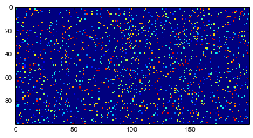

```python
import matplotlib.pyplot as plt
plt.imshow(R.todense(), interpolation='nearest')
```

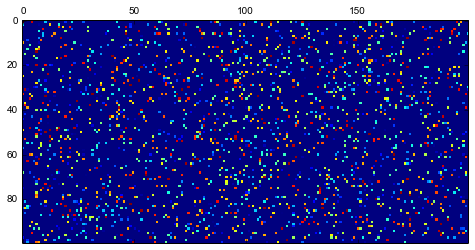

```python
from pylab import *
matshow(R.todense())
```

#### Memory occupation

In numpy and scipy it is possible to read the number of bytes occupied by an array with th eattribute `nbytes`. Hence:

```python
sp.arange(100).nbytes
```

```
800
```

```python
R.data.nbytes
```

```
16000
```

```python
R.data.nbytes + R.indptr.nbytes + R.indices.nbytes
```

```
24804
```